# Machine Learning - Human Activity Recognition

Larry Brown

10/23/2021

# Introduction

This goal of this project is to use data from accelerometers on the belt, forearm, arm, and dumbbell of 6 participants doing exercises and develop a model that predicts the manner in which the individual did the exercise (how well performed the exercise). Six participants performed one set of 10 repetitions of the Unilateral Dumbbell Biceps Curl in five different fashions:

```
 Class A - exactly according to the specification
 Class B - throwing the elbows to the front
 Class C - lifting the dumbbell only halfway
 Class D - lowering the dumbbell only halfway
 Class E - throwing the hips to the front
```

## Data Preprocessing

The original data set consists of training set of 19,622 observations of 160 variables, requiring clean-up of not applicable data. A validation set of 20 observations and 160 is also available to validate the final prediction model. The first 7 columns of the data set contain information, not relevant to the accelerator data for predicting a model, for instance, the user name and time of day for collecting data. See table below. Furthermore, a large number of variables have missing data. If the number of N/A > 1000, the variable was removed from the data set.

```r
training_set <- read.csv("data/pml-training.csv", na.strings=c("NA","#DIV/0!", " "))
validation_set <- read.csv("data/pml-testing.csv", na.string=c("NA","#DIV/0!", " "))

head(training_set[,1:7], 5)
```

```
##   X user_name raw_timestamp_part_1 raw_timestamp_part_2   cvtd_timestamp
## 1 1  carlitos           1323084231               788290 05/12/2011 11:23
## 2 2  carlitos           1323084231               808298 05/12/2011 11:23
## 3 3  carlitos           1323084231               820366 05/12/2011 11:23
## 4 4  carlitos           1323084232               120339 05/12/2011 11:23
## 5 5  carlitos           1323084232               196328 05/12/2011 11:23
##   new_window num_window
## 1         no         11
## 2         no         11
## 3         no         11
## 4         no         12
## 5         no         12
```

```r
# Identify columns with more than 1,000 N/A to drop
drop_cols <- names(training_set[ ,apply(is.na(training_set), 2, sum) > 1000 ])
# Add first seven columns to names to drop
drop_cols <- c(names(training_set[,1:7]), drop_cols)

# Drop columns
training_set <- subset(training_set, select = !(names(training_set) %in% drop_cols))
validation_set <- subset(validation_set, select = !(names(validation_set) %in% drop_cols))
```

# Data Partitioning

The reduced data sets comprise 53 variables, for which the original data set was split into a ‘training’ and a ‘testing’ data set, using a 70% random split of the data. The training set comprised 13,737 observations and the testing set compromised 5,885 observations.

```r
set.seed(12345)

inTrain <- createDataPartition(y=training_set$classe, p=0.70, list=FALSE)
training <- training_set[inTrain, ]
testing <- training_set[-inTrain, ]
```

## Model Development

The model development looked at several classification approaches and evaluating the accuracy of each model against the partitioned testing data set. The models under considerations:

1. Basic Classification Tree
2. Random Forest
3. Booting

Based on selecing the best model based on the accuracy against the testing set, further analysis was considered using Principal Component Analysis for generating a new subset of variable s(principal components) and to seeing if this approach improved the model.

### Basic Classifcation Tree

The tuning variable for the Classification Tree is the complexity parameter, cp. By default, the caret rpart method performed a 3-point grid search, with cp values of (0.0356, 0.0609, 0.1160) yielding an accuracy of (0.505, 0.418, 0.337), respectively. The model shows a increasing accuracy for decreasing complexity parameter. With this information a classification tree was trained using cp grid values of (0, 0.001, 0.01). the best model is cp=0 with an accuracy of 0.937.

```r
# Decision Tree with three complexity parameter values
set.seed(358)
modFit_ct = train(classe ~ ., data=training, method = "rpart")

modFit_ct = train(classe ~ ., data=training, method = "rpart",
                  tuneGrid = data.frame(cp = c(0, 0.001, 0.01)))

# Predict values based on best model and testing data set
predict_ct <- predict(modFit_ct, newdata=testing, method="class")
cm <- confusionMatrix(data=predict_ct, reference=as.factor(testing$classe))
cm$overall["Accuracy"]
```

```
##  Accuracy
## 0.9369584
```

```r
cm$table
```

```
##           Reference
## Prediction    A    B    C    D    E
##          A 1629   37   11    5    4
##          B   27 1023   54   16   22
##          C    4   31  930   19   10
##          D   10   19   23  899   13
##          E    4   29    8   25 1033
```

### Random Forest

```r
modFit_rf <- train(classe ~., method="rf", data=training)

# Perform prediction
predict_rf <- predict(modFit_rf, testing)
cm_rf <- confusionMatrix(data=predict_rf, reference=as.factor(testing$classe))

cm_rf$overall["Accuracy"]
```

```
##  Accuracy
## 0.9949023
```

```r
cm_rf$table
```

```
##           Reference
## Prediction    A    B    C    D    E
##          A 1673    4    0    0    0
##          B    1 1135    4    0    0
##          C    0    0 1022   21    0
##          D    0    0    0  943    0
##          E    0    0    0    0 1082
```

[output not shown]

[output not shown]

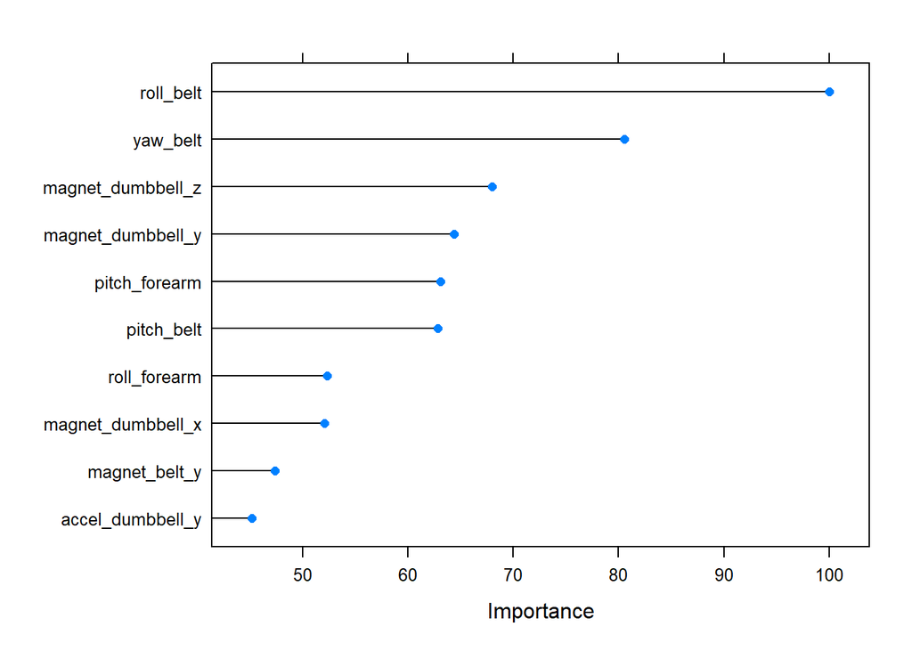

```r
# Show top 10 features from Random Forest
feature_importance <- varImp(modFit_rf)
plot(feature_importance, top=10)
```

## Stochatic Gradient Boosting

```r
# Boosting classification model
modFit_gbm <- train(classe ~., method="gbm", data=training, verbose=FALSE)

# Predict against testing set
predict_gbm <- predict(modFit_gbm, testing)
cm_gbm <- confusionMatrix(data=predict_gbm, reference=as.factor(testing$classe))
cm_gbm$overall["Accuracy"]
```

```
##  Accuracy
## 0.9588785
```

```r
cm_gbm$table
```

```
##           Reference
## Prediction    A    B    C    D    E
##          A 1647   37    0    0    2
##          B   20 1060   37    2   17
##          C    3   34  977   39    5
##          D    4    5   12  915   14
##          E    0    3    0    8 1044
```

## Final Model Selection

Following is the overall accuracy results for the three models, against the testing data set:

[output not shown]

```r
# Generate principal components and transform the training and testing data sets
preProc = preProcess(training, method=c("center", "scale", "pca"),
                     thresh = 0.80)
training_PCA <- predict(preProc, training)
testing_PCA <- predict(preProc, testing)

# Random Forest using PCA reduced data
modFit_rfpca <- train(classe ~., method="rf", data=training_PCA)
# Perform prediction
predict_rfPCA <- predict(modFit_rfpca, testing_PCA)
cm_rfPCA <- confusionMatrix(data=predict_rfPCA, reference=as.factor(testing$classe))
cm_rfPCA$overall["Accuracy"]
```

```
##  Accuracy
## 0.9615973
```

```r
cm_rfPCA$table
```

```
##           Reference
## Prediction    A    B    C    D    E
##          A 1634   33    8    7    1
##          B   14 1081   14    4   11
##          C   18   20  990   55    4
##          D    7    5   12  894    6
##          E    1    0    2    4 1060
```

## Prediction on Validation Set

Finally, the Random Forest model yields the following results on the 20 observations in the validation set (data unseen during the model training and evaluation process). The model was able to correctly classify all 20 observations.

```r
# Perform prediction on validation set
predict_validation <- predict(modFit_rf, validation_set)
predict_validation
```

```
##  [1] B A B A A E D B A A B C B A E E A B B B
## Levels: A B C D E
```

#### References

[http://topepo.github.io/caret/available-models.html]http://topepo.github.io/caret/available-models.html [http://web.archive.org/web/20161224072740/http:/groupware.les.inf.puc-rio.br/har]http://web.archive.org/web/20161224072740/http:/groupware.les.inf.puc-rio.br/har